# (Ford GoBike System Data)

## by (Salma Gouda)

## Investigation Overview

> The overall goal of my presentation is to illustrate how different features interact with trip duration.

## Dataset Overview

> The datasets contains 174,952 trips further detailed in 13 columns ('duration_sec', 'start_time', 'end_time', 'start_station_name', 'end_station_name', 'bike_id', 'user_type', 'member_birth_year', 'member_gender', 'bike_share_for_all_trip', 'age', 'month', 'duration_min'). Some variables are numeric in nature, while others are categorical.

## (Visualization 1)

> What's the distribution of different ages?
> - The age distribution histogram is rightly skewed with a peak around 28 to 32 ages.
> - We can conclude that the larger no. of trips and trip durations belong to people around 30 as most users in the dataset are around this age.

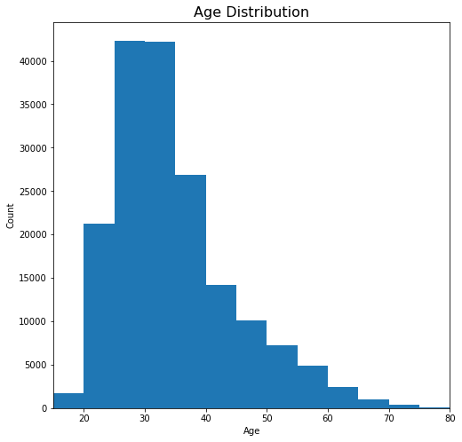

## (Visualization 2)

> What's the count of each gender in different user types?
> - The bar plot shows that male count is much more higher than female count in both user types.
> - In conclusion, there are higher contributions of the male gender because the users in this dataset are mostly males.

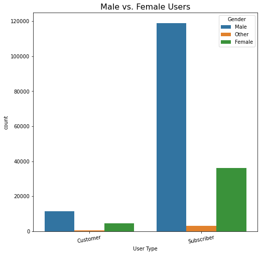

## (Visualization 3)

> - How does the no. of trips change among users of different ages?
> - For both subscribers and customers, the number of trips decreases as age increases, with a peak around the age of 30.

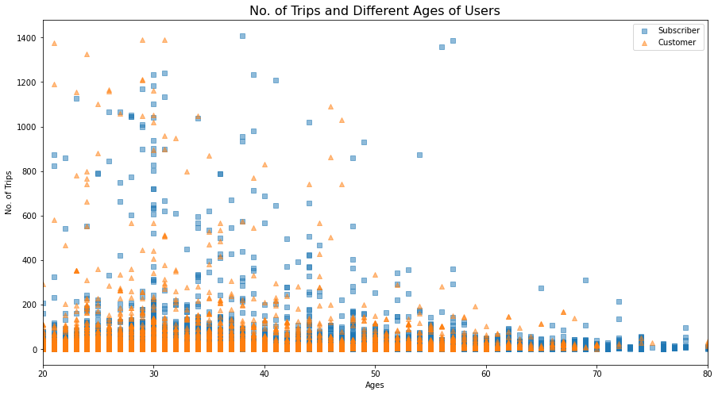